# Workshop: Dynamic Analysis of Aspiration

Johanna Cronenberg

August 2021

```r
library(MuMIn)
library(optimx)
library(lmerTest)
library(emmeans)
library(emuR)
library(wrassp)
library(signal)
library(tools)
library(data.table)
library(fda)
library(abind)
library(tidyverse)
library(magrittr)
```

# 1 Methodology

## 1.1 Thinking backwards

We need:

- numbers to statistically test whether age, region, cluster influence pre-/post-aspiration production
- a technique to transform some kind of speech-derived signal (because this is a dynamic technique) into numbers
- speech-derived signals that are adequate for quantifying aspiration
- acoustic data

And in more details:

- For stats, we need a data frame that contains the fixed effect variables, the random variables (speaker, word), as well as the numeric measure of aspiration
- For FPCA, we need a data frame of several observations per token, where each observation is one point in time along the derived acoustic signals; we need one column per acoustic signal and an identifier to match this data frame to the stats data frame
- The signals should represent the glottal gesture (voicing) and the oral closure; we need to find boundaries to cut of the signals at appropriate points (during the vowels), i.e. we need to find the point of highest VP during V1 and V2
- Since VP is between 0 and 1, HF needs to be in approx. the same range of values; HF should also be amplitude-normalised for comparability, i.e. we need to find the lowest energy during the closure
- The audio data should be segmented automatically and stored in a database for convenience

## 1.2 Planning forwards

1. Create a database: Collect audio data, orthographically transcribe audio, create emuDB, automatically segment speech
2. Compute HF & VP (+ check for a few files)
3. Define sequence: Find closure in HF, db-normalise HF, find max VP during vowels, cut signals at boundaries
4. Optional: check more tokens and discard outliers
5. Create data frames for statistical analysis
6. FPCA + interpretation
7. Mixed Model

# 2 Data Processing

## 2.1 Creating the emuDB

We have recorded Andalusian speakers producing single words containing “st”, “sp”, and “sk”. We now have audio files whose names are composed of the speaker code (e.g. ACM0011), the cluster sequence (e.g. sp), the produced word (e.g. caspa), and the repetition (e.g. 1). In order to generate an emuDB, we need text files of matching names that contain an orthographic transcript of what was spoken (with errors, hesitations, etc.). The easiest way to do that for this pre-selected data is by executing the python script `create_text.py` in Python 3 (which has already been done; see the results in folder `data`).

The matching wav and txt files can then be transformed into an [emuDB](https://ips-lmu.github.io/The-EMU-SDMS-Manual/index.html):

```r
# ONLY EXECUTE ONCE!
convert_txtCollection(dbName = "anda",
                      sourceDir = "./data",
                      targetDir = "./")
```

```r
db <- load_emuDB("anda_emuDB")
```

```
## INFO: Checking if cache needs update for 1 sessions and 581 bundles ...
## INFO: Performing precheck and calculating checksums (== MD5 sums) for _annot.json files ...
## INFO: Nothing to update!
```

Having loaded the emuDB into a variable called `db` here, we can always check the contents and state of the database by means of:

```r
summary(db)
```

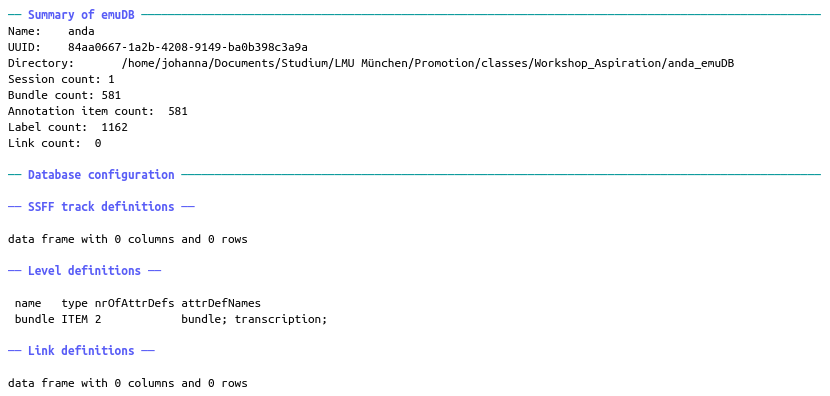

Next, we can use the [BAS Webservices](https://clarin.phonetik.uni-muenchen.de/BASWebServices/interface) in order to automatically segment and phonologically transcribe our data. We need three of the BAS Webservices for that: G2P (grapheme to phoneme) for tokenization and pronunciation as well as MAUS (Munich Automatic Segmentation). Spanish is luckily one of the many languages that MAUS has been trained for. This process can take a while and needs an internet connection.

```r
# ONLY EXECUTE ONCE!
runBASwebservice_g2pForTokenization(handle = db,
                                    transcriptionAttributeDefinitionName = "transcription",
                                    language = "spa-ES",
                                    orthoAttributeDefinitionName = "word")

runBASwebservice_g2pForPronunciation(handle = db,
                                     language = "spa-ES",
                                     orthoAttributeDefinitionName = "word",
                                     canoAttributeDefinitionName = "ort")

runBASwebservice_maus(handle = db,
                      language = "spa-ES",
                      canoAttributeDefinitionName = "ort",
                      mausAttributeDefinitionName = "phonetic",
                      params = list(OUTSYMBOL="sampa"))
```

The summary now shows that there are several new levels stored on the database.

```r
summary(db)
```

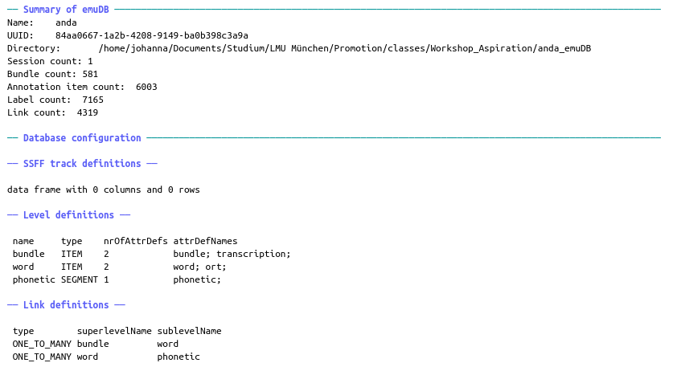

Amazingly, we can also take a look at our database using `serve()`:

```r
serve(db)
```

## 2.2 Computing HF

HF is the high-frequency (> 3000 Hz) energy, smoothed by a Butterworth filter. This signal will represent the oral closure gesture and can also show when there is a lot of friction noise (which typically occurs in high frequencies). We can use functions from the `wrassp` package for the signal processing that is necessary to compute HF.

```r
# EXECUTE ONLY ONCE!

# list wav files
path <- file.path("./anda_emuDB")
wav_paths <- list.files(path, pattern = ".*wav$", recursive = T, full.names = T)

# central difference once
afdiff(wav_paths, computeCentralDifference = T)
# and again (creates ddwav)
dwav_paths <- list.files(path, pattern = ".*dwav$", recursive = T, full.names = T)
afdiff(dwav_paths, computeCentralDifference = T)

# high pass filter
ddwav_paths <- list.files(path, pattern = ".*ddwav$", recursive = T, full.names = T)
affilter(ddwav_paths, highPass = 3000)

# list high-pass filtered files
hpf_paths <- list.files(path, pattern = ".*hpf$", recursive = T, full.names = T)

# apply log rms
rmsana(hpf_paths, linear = F, explicitExt = ".rms")
rms_paths <- list.files(path, pattern = ".*rms$", recursive = T, full.names = T)

# smooth with 20 Hz Butterworth filter
for(j in 1:length(rms_paths)) {
  ado <- read.AsspDataObj(rms_paths[j])
  bf <- butter(n = 2, W = 0.2, type = "low")
  ado$rms <- as.matrix(filtfilt(bf, ado$rms))
  write.AsspDataObj(ado, file = paste0(".", splitstring(rms_paths[j], ".")[1], ".rmsx"))
}

# add track rmsx to the database
add_ssffTrackDefinition(db, name = "HF", columnName = "rms", fileExtension = "rmsx")

summary(db)
```

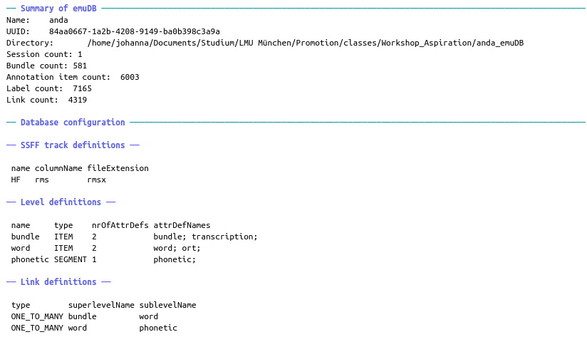

## 2.3 Computing VP

VP is the voicing probability, which is computed using the PEFAC algorithm (Gonzalez & Brookes 2014) in MATLAB. It represents the glottal gesture. Together, HF and VP represent how articulatory gestures are time-aligned when producing a voiceless plosive with aspiration phases. In theory, when there is no voicing (VP is low) and there is lots of energy in the higher frequencies (HF is high), there should be aspiration in the speech signal.

Open MATLAB (version R2017b) and change the working directory to `voicebox/voicebox`. Open the script `run_PEFAC.m` in MATLAB and adapt the path in the first line. Now you should be able to run the script `run_PEFAC.m` in MATLAB without any errors. In the console, it should display the names of the files that the algorithm is working on. When the script is done, you should find files with the extension `.vp` in your data base.

Unfortunately, these new files need to be corrected slightly by adding zeros at the very beginning and end of the speech signal and they need to be transformed into the SSFF format in order to be added to the database. We have written a function called `vp2assp()` for that.

```r
vp2assp <- function(path) {
  df <- read.table(path, header = F, sep = "\t")

  # add zeros at beginning of signal, because PEFAC values usually start at ~0.045
  while (df[1,2] > 0.0005) {
    newRow <- c(0.0, df[1,2]-0.005)
    df <- rbind(newRow, df)
  }

  wavPath <- paste0(substr(path, 1, nchar(path)-3), ".wav")
  wav <- read.AsspDataObj(wavPath)
  dur <- attr(wav, "endRecord") / attr(wav, "sampleRate")

  # also, if PEFAC has not computed values until the end of the signal, add zeros
  while (df[nrow(df),2] < dur) {
    newRow <- c(0.0, df[nrow(df),2]+0.005)
    df <- rbind(df, newRow)
  }

  df <- as.matrix(df)

  ado <- list()
  attr(ado, "sampleRate") <- 200
  attr(ado, "origFreq") <- 44100
  attr(ado, "startTime") <- as.numeric(df[1,2])
  attr(ado, "endTime") <- as.numeric(df[nrow(df),2])
  attr(ado, "endRecord") <- as.numeric(nrow(df))
  class(ado) <- "AsspDataObj"
  AsspFileFormat(ado) <- "SSFF"
  AsspDataFormat(ado) <- as.integer(2)

  attr(ado, "trackFormats") <- "REAL32"
  ado <- addTrack(ado, trackname = "voiceProb", data = df[,1], format = "REAL32")
  return(ado)
}
```

Let’s run this function on all of our voicing probability files and add the new VP track to our database.

```r
# EXECUTE ONLY ONCE

# list all .vp files in the emuDB
vp_paths <- list.files(path, pattern = "*.vp$", recursive = T, full.names = T)

# convert files to SSFF format
for(p in vp_paths) {
  ado <- vp2assp(p)
  write.AsspDataObj(ado, file = paste0(file_path_sans_ext(p), ".voiceProb"))
}

# add VP to db
add_ssffTrackDefinition(db, name = "VP", columnName = "voiceProb", fileExtension = "voiceProb")
```

Finally, we can inspect HF and VP for each file of the database.

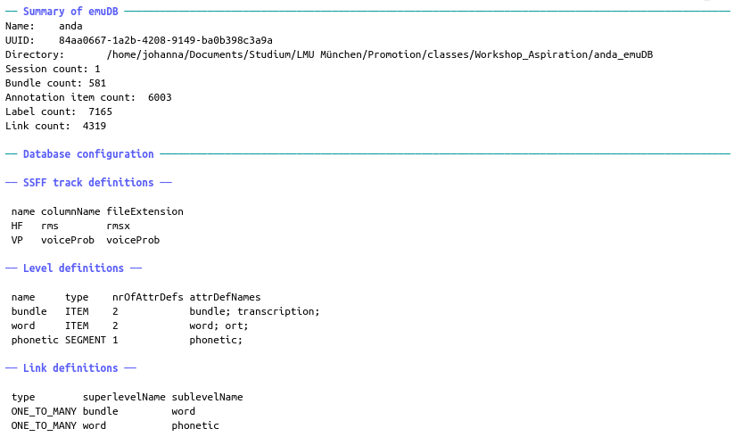

```r
summary(db)
set_signalCanvasesOrder(db, perspectiveName = "default", order = c("OSCI", "SPEC", "HF", "VP"))
serve(db)
```

## 2.4 Normalising HF

The HF signal is highly sensitive to the overall energy in the speech signals, i.e. if someone produced a word much louder, the HF signal for that word is going to be much higher overall than for a word that was produced quietly. Since this can be a confusing factor in our statistical analysis later, we are going to amplitude-normalise the HF signal. In order to do so, we will look for the HF minimum during the closure and subtract that value from the whole HF signal.

This is where the database structure of emu and the automatic segmentation will help us immensely. Using the [Emu Query Language (EQL)](https://ips-lmu.github.io/The-EMU-SDMS-Manual/chap-querysys.html), we can ask for all sequences of phonemes that start with a vowel, followed by /s/, followed by /k, t, p/, followed again by vowels (or glides).

```r
sequences <- query(db, "[[[phonetic == e | a | o | i -> phonetic == s] ->
                   phonetic == k | p | t] ->
                   phonetic == u | i | w | a | j | o]")
```

For these sequences we can now easily extract the HF and VP signals.

```r
hf.df <- get_trackdata(db, seglist = sequences, ssffTrackName = "HF")
vp.df <- get_trackdata(db, seglist = sequences, ssffTrackName = "VP")
```

Our next step is the db-normalisation. Since we don’t know exactly where the closure occurs, we will instead ask the emuDB where the voiceless plosives occur in our /VsCV/ sequences and extract HF for these plosives.

```r
plosives <- query(db, "[[[phonetic == e | a | o | i -> phonetic == s] ->
                  #phonetic == k | p | t] ->
                  phonetic == u | i | w | a | j | o]")
minClosure.df <- get_trackdata(db, seglist = plosives, ssffTrackName = "HF")
```

Now we will look for the lowest point of HF for each token and subtract that from the rest of the HF signal which we extracted earlier.

```r
minClosure.df %<>%
  # for each token
  group_by(sl_rowIdx) %>%
  # only retain observation with lowest HF
  filter(T1 == min(T1)) %>%
  # rename and select columns
  rename(HFmin = T1, HFmin_time = times_norm) %>%
  select(sl_rowIdx, HFmin, HFmin_time)

hf.df %<>%
  # rename T1 to HF
  rename(HF = T1) %>%
  # add HFmin and HFmin_time to hf.df for each token
  left_join(minClosure.df, by = "sl_rowIdx") %>%
  # create column HFnorm as difference of HF and HFmin
  # also transform relative times to rounded numbers
  mutate(HFnorm = HF-HFmin,
         times_rel = as.numeric(format(5*round(times_rel/5), scientific = T)))
```

Be aware that we are doing all of these calculations outside of the database, i.e. we are not adding a normalised HF signal to the database.

## 2.5 Defining the Sequence

We are not interested in the whole words, rather we want to select a sequence within the words that is comparable across utterances. We have chosen to analyse the sequence from the points of highest voicing probability in the two vowels surrounding the /sC/ cluster. That is why we ask the emuDB for the two vowels V1 and V2 first, extract VP for the vowels, and then search for the last time point in V1 and the first time point in V2 which has the highest peak of VP.

```r
v1 <- query(db, "[[[#phonetic == e | a | o | i -> phonetic == s] ->
            phonetic == k | p | t] ->
            phonetic == u | i | w | a | j | o]")
v2 <- query(db, "[[[phonetic == e | a | o | i -> phonetic == s] ->
            phonetic == k | p | t] ->
            #phonetic == u | i | w | a | j | o]")

v1.vp <- get_trackdata(db, seglist = v1, ssffTrackName = "VP")
v2.vp <- get_trackdata(db, seglist = v2, ssffTrackName = "VP")

v1.vp %<>%
  # for each token
  group_by(sl_rowIdx) %>%
  # only retain observation(s) of highest VP
  filter(T1 == max(T1)) %>%
  # only retain latest of these observations
  slice_max(times_orig, n = 1) %>%
  ungroup() %>%
  rename(sequenceStart = times_orig, v1.VPmax = T1) %>%
  select(sl_rowIdx, sequenceStart, v1.VPmax)

v2.vp %<>%
  # for each token
  group_by(sl_rowIdx) %>%
  # only retain observation(s) of highest VP
  filter(T1 == max(T1)) %>%
  # only retain earliest of these observations
  slice_min(times_orig, n = 1) %>%
  ungroup() %>%
  rename(sequenceEnd = times_orig, v2.VPmax = T1) %>%
  select(sl_rowIdx, sequenceEnd, v2.VPmax)
```

The data frames `v1.vp` and `v2.vp` contain the cut-off points for the sequences that we want to analyze.

# 3 Composing Data Frames

Now we can join everything that we have worked on up to this point. First, we’re cutting off HF and VP at the determined boundaries:

```r
hf.df %<>%
  # add cut-off point in V1
  left_join(v1.vp, by = "sl_rowIdx") %>%
  # add cut-off point in V2
  left_join(v2.vp, by = "sl_rowIdx") %>%
  # round original times
  mutate(times_orig = as.numeric(format(5*round(times_orig/5), scientific = T))) %>%
  # cut HF signal at boundaries
  filter(times_orig >= sequenceStart & times_orig <= sequenceEnd)

# same for VP
vp.df %<>%
  left_join(v1.vp, by = "sl_rowIdx") %>%
  left_join(v2.vp, by = "sl_rowIdx") %>%
  mutate(times_orig = as.numeric(format(5*round(times_orig/5), scientific = T))) %>%
  filter(times_orig >= sequenceStart & times_orig <= sequenceEnd) %>%
  rename(VP = T1) %>%
  select(sl_rowIdx, times_orig, VP)
```

The first data frame, `trajectories` contains the HF and VP signals for each token. Importantly, we need to re-adjust the relative and normalised time points in this data frame since they aren’t correct anymore after we have cut the signals.

```r
trajectories <- hf.df %>%
  # add VP
  left_join(vp.df, by = c("sl_rowIdx", "times_orig")) %>%
  # select columns
  select(-c(start_item_id, end_item_id, level, attribute, start_item_seq_idx, end_item_seq_idx,
            type, HFmin, HFmin_time, sequenceStart, v1.VPmax, sequenceEnd, v2.VPmax)) %>%
  # for each token
  group_by(sl_rowIdx) %>%
  # re-adjust relative and normalised time
  mutate(times_rel = seq(0, to = (n()-1)*5, by = 5),
         times_norm = seq(0, 1, length.out = n())) %>%
  ungroup()
# write.table(trajectories, "./trajectories.txt")
```

The second data frame, `info`, will be handy for the mixed models later, so we will store in it the interesting values we have computed as well as all speaker/item information that will be used as fixed or random effects.

```r
info <- hf.df %>%
  # select columns
  select(sl_rowIdx, labels, start, end, db_uuid, session, bundle, HFmin,
         HFmin_time, sequenceStart, sequenceEnd, v1.VPmax, v2.VPmax) %>%
  # only retain one observation per token
  unique() %>%
  # create columns speaker, word, and repetition from bundle
  separate(bundle, into = c("speaker", "word", "rep"), sep = "_", remove = FALSE) %>%
  # remove unnecessary/wrong columns
  select(-c(speaker, rep)) %>%
  # add information on items and speakers
  mutate(speaker = substring(as.character(bundle), 1, 7),
         speaker = ifelse(speaker == "JGM0006", "JGM0007", speaker),
         age = ifelse(speaker %in% c("ACM0011", "ALR0012", "AMU0049", "ATO0020", "CBD0026", "CDT0024", "CFL0032", "CNJ0052",
                                     "CSL0030", "FGC0019", "FGC0062", "FPS0060", "IPL0006", "JMG0040", "JML0039", "JRF0002",
                                     "JRS0033", "LUR0016", "MBC0034", "MGR0016", "MQG0003", "PAM0022", "POR0017", "RHB0004"),
                      "older", "younger"),
         region = ifelse(speaker %in% c("ACM0011", "ADG0021", "AGR0009", "ALR0012", "ATO0020", "AUN0059", "BGG0008", "CAR0005",
                                        "CBD0026", "CDT0024", "DBM0004", "EPC0058", "FGC0019", "FGC0062", "FPS0060", "IPL0006",
                                        "JGM0007", "JMP0002", "LHS0003", "MGR0016", "NPG0010", "PAM0022", "PMY0005", "POR0017"),
                         "West", "East"),
         cluster = case_when(word %in% c("caspa", "despide", "despierta", "despues", "disputa", "espada",
                                         "espalda", "espana", "espanto", "espia", "espiaba", "espiando",
                                         "espina", "espuela", "espuma", "esputo", "respira") ~ "sp",
                             word %in% c("cosquillas", "escama", "escapa", "escaso", "escucha", "escudo",
                                         "escuela", "escueto", "escupe", "esquia", "esquiando", "esquife",
                                         "esquina", "pescado", "vasca") ~ "sk",
                             TRUE ~ "st"))
```

# 4 Statistical Analysis

## 4.1 FPCA

The first step in our statistical analysis is [Functional Principal Component Analysis (FPCA)](http://lands.let.ru.nl/FDA/). This technique will find the main dimensions of variation in our HF and VP signals. We expect that one dimension might capture where the closure occurs with respect to the voiceless interval: if the closure occurs in-phase (anti-phase) with the start of the voiceless interval, there should be time for post-aspiration (pre-aspiration), given that the duration of the closure is relatively stable. Differently put, we expect there to be a dimension of variation that not only captures pre- and post-aspiration, but might also uncover a relation between the two.

FPCA decomposes the input signals into a linear combination of the mean signals plus the (sum over) the Principal Components multiplied by their PC score. So the result of FPCA consists of three objects:

- Mean signals: the mean HF and VP signal
- Principal Components (PCs): time-varying curves that capture an independent dimension of variation in the input signals’ shapes
- PC scores (one per input signal per PC): weights that determine how much of a specific kind of variation is present in a specific input signal

The linearity of this operation makes it a fast process and facilitates the reconstructions of signals as we shall see later.

Apart from the general FPCA functions that are provided by `fda`, we’ll need one more function:

```r
getPCscores <- function(fpcaObj) {
  if (is.matrix(fpcaObj$scores)) {
    fpcaObj$scores
  } else if (is.array(fpcaObj$scores) & length(dim(fpcaObj$scores)) == 3) {
    apply(fpcaObj$scores, 1:2, sum)
  } else {
    stop("getPCscores: invalid input fpcaObj")
  }
}
```

Let’s prepare everything for FPCA:

```r
trajectories %>% setorder(bundle, times_rel)
info %>% setorder(bundle) %>% setDT

# check that the bundle order is the same
all.equal(trajectories$bundle %>% unique, info$bundle)
```

```
## [1] TRUE
```

```r
# set parameters
nKnots <- 10
lambda <- 1e-7
Lfdobj <- 2
nOrder <- 2 + Lfdobj
nBasis <- nKnots + nOrder - 2

# create a basis for B-splines
basis <- create.bspline.basis(rangeval = c(0, 1), nbasis = nBasis, norder = nOrder)

# define functional parameter object (will be used to estimate functional parameters later)
fdParObj <- fdPar(fdobj = basis, Lfdobj = Lfdobj, lambda = lambda)
```

FPCA is sensitive to the range of values in signals. We know that VP is fixed between 0 and 1, but HF can take a huge range of values. FPCA, if applied to the current VP and HF signals, will therefore find much larger variations in HF compared to VP. That is why we need to re-scale HF such that it ranges approximately between 0 and 1 (but it can go beyond). We will do this by dividing `HFnorm` by the 50th percentile over all normalised HF values. The exact percentile can be adjusted as needed to control the HF range (e.g. in the JPhon study, we used the 75th percentile).

Having re-scaled HF, we can then apply the B-splines smoothing and bring the result into a form that is accepted by FPCA.

```r
# compute 50th percentile
hf.quantile <- quantile(trajectories$HFnorm, .5)

coef <- trajectories %>%
  # re-scale HF to approx. 0-1
  mutate(HFnorm = HFnorm/hf.quantile) %>%
  # transform to long form
  pivot_longer(cols = c("VP", "HFnorm"), names_to = "signal", values_to = "value") %>%
  # for each token and signal (VP or HFnorm)
  group_by(sl_rowIdx, signal) %>%
  # apply B-splines for smoothing
  summarise(coef = c(smooth.basis(argvals = times_norm, y = value, fdParObj)$fd$coefs),
            # coefId is needed for pivoting
            coefId = seq_len(nBasis)) %>%
  # from here on, we tranform the data into the appropriate form for FPCA
  pivot_wider(names_from = coefId, values_from = coef) %>%
  # create a list of two tibbles, one for each signal
  group_by(signal) %>%
  group_map(~ select(.x, -sl_rowIdx)) %>%
  # create 3D-array
  abind(along = 3) %>%
  # order array dimensions: smoothing basis (12), n_curves (581), signals (2)
  aperm(c(2,1,3))
# check class and dimension
coef %>% class # array
```

```
## [1] "array"
```

```r
coef %>% dim   # 12 581   2
```

```
## [1]  12 581   2
```

The final step here is to compute the Principal Components (i.e. the dimensions of variation); here we chose to compute the first four.

```r
# create functional data object
y_fd <- fd(coef = coef, basisobj = basis)

# this is the actual FPCA
nPCs <- 4
y_pcafd <- pca.fd(y_fd, nharm = nPCs, fdParObj)
# saveRDS(y_pcafd, file = "./pcafd.rds")
```

An interesting measure is the amount of variance captured by each of the four PCs, which can be found in the PCA object.

```r
y_pcafd$varprop # 0.53140722 0.24884075 0.09117602 0.03740262
```

```
## [1] 0.53140722 0.24884075 0.09117602 0.03740262
```

That is, PC1 captures 53.1% of all variance in the signal shapes of HF and VP, PC2 captures 24.9%, and so on. It is by default, that the amount of variance captured declines, i.e. PC1 always describes the largest amount of variance. However, this does not mean that PC1 is also necessarily the most *relevant* to our research question! We will take a look at the interpretation of the PC1 to PC3 in the next section (PC4 describes only a very small amount of variance).

Besides the PCs, FPCA also returns PC scores (one per PC per input token) which determine how much of one dimension of variance is present in a certain token. Let’s add the PC scores to our `info` data frame (even though PC scores have nothing to do with time).

```r
info %<>%
  cbind(y_pcafd %>% getPCscores) %>%
  rename(s1 = V1, s2 = V2, s3 = V3, s4 = V4)
# write.table(info, "./info.txt")
```

## 4.2 Interpretation

It is very important to understand what kind of variation was captured by the PCs. In order to do that we visualize how extreme PC scores will change the signal shapes. That is why we compose a data frame called `curves` which holds the combination of the two signals, HF and VP, the three PCs and three perturbation values. These three values represent plus/minus one standard deviation of the given PC’s score, as well as zero for the mean HF and VP signals. The plot will make that a little clearer.

```r
tx <- seq(1/1000, 1, by = 1/1000)
SignalIndex <- list("HF" = 1, "VP" = 2)

# compose data frame
curves <- expand.grid(time = tx,
                      Signal = SignalIndex %>% names,
                      PC = 1:3,
                      perturbation = c(-1, 0, 1)
) %>% setDT

# standard deviations of the first three PC scores
sd_score <- info %>% summarise_at(vars(s1:s3), sd) %>% as.numeric()
```

The next piece of code uses the `data.table` syntax to efficiently reconstruct the HF and VP signals from the functional data model, i.e. from the mean signals, the PCs, and PC scores. Here, we only ever add one PC to the mean signals (and set the other PCs to zero) as we want to know what kind of variation of captured by each PC separately.

```r
# mean + perturbation * standard dev of PC score * PC
curves[, value := (y_pcafd$meanfd$coefs[,1,Signal] + perturbation * sd_score[PC] * y_pcafd$harmonics$coefs[,PC,Signal]) %>%
         # transform into functional data object
         fd(., basis) %>%
         # evaluate this functional data at the timepoints given by tx
         eval.fd(tx, .),
       # do this separately by PC, Signal, and perturbation
       by = .(PC, Signal, perturbation)]
```

Now we can finally create a line plot to interpret the PCs.

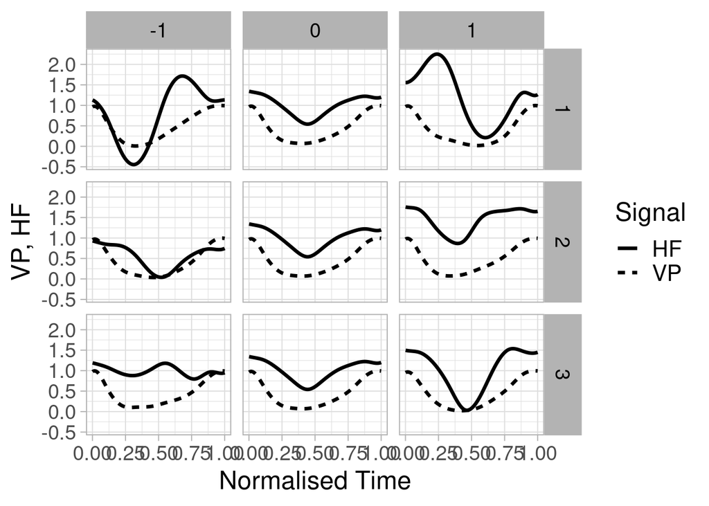

```r
ggplot(curves) +
  aes(x = time, y = value, linetype = Signal) +
  geom_line(size = 1.2) +
  facet_grid(PC~perturbation) +
  xlab("Normalised Time") + ylab("VP, HF") +
  theme_light(base_size = 16) +
  theme(text = element_text(size = 18),
        strip.text.x = element_text(color = "black"),
        strip.text.y = element_text(color = "black"),
        legend.text = element_text(size = 16))
```

The middle column of this plot is the same in all three rows and shows the mean HF and VP signals. PC1 (first row) seems to describe a shift in the location of the closure. When s1 (the score associated with PC1) is negative, the closure occurs early, thereby leaving space and time for post-aspiration, and the opposite holds for a positive s1. PC2 (second row) captures the overall height of the HF signal – this may well be an effect of the distance between speaker and microphone or the volume. The higher s2, the higher the overall HF signal, i.e. the more energy was generally in the input signal. PC3 (third row) seems to capture the depth of the HF minimum, from hardly any minimum (left column) to a very pronounced dip in the HF signal (right column). That is, PC3 may capture something like the “cleanness” of the closure. But it is very hard to tell without using further statistics (and even then, some speculation may remain).

But in conclusion, PC1 actually describes the kind of variation that we were interested in to begin with: the position of the closure which, as a consequence, determines the presence or absence of pre- and post-aspiration. For the rest of this analysis, we’ll focus on PC1.

## 4.3 Area Computation

As explained in the JPhon paper, we take the positive area between HF and VP as a measure of aspiration strength, because aspiration consists of no closure and high friction noise (i.e. high HF) as well as voicelessness (low VP). We will need a few self-written functions in order to compute the area between HF and VP:

```r
# compute time interval where HF > VP
PositiveIntervals <- function(HF.fd, VP.fd, dt = 1/1000) {
  DT <- data.table(tx = seq(0, 1, by = dt))
  DT[, IsPositive := (HF.fd - VP.fd) %>%
       eval.fd(tx, .) %>%
       `>` (0)
     ]
  DT[, .(start = tx[1], end = tx[.N], IsPositive = .SD[1, IsPositive]),
     by = rleid(IsPositive),
     .SDcols = c("tx", "IsPositive")] %>%
    .[IsPositive == TRUE, .(start, end)]
}

# compute the time of the HF minimum in the reconstructed signal using only PC1
argminHFs1 <- function(s1) {
  (y_pcafd$meanfd$coefs[,1,SignalIndex$HF] + s1 * y_pcafd$harmonics$coefs[,1,SignalIndex$HF]) %>%
    fd(basis) %>%
    eval.fd(tx, .) %>%
    which.min %>%
    `/`(1000)
}
argminHFs1 %<>% Vectorize

# compute the definite integral
defint.fd <- function(fdobj, rng=NULL) {
  if (is.null(rng)) { rng = fdobj$basis$rangeval }
  return (apply(inprod(fdobj,fdobj$basis,rng=rng),1,sum))
}

# compute areas between the PC1-reconstructed signals
computeAs1 <- function(s1, interval = 0) {
  HF.fd <- (y_pcafd$meanfd$coefs[,1,SignalIndex$HF] + s1 * y_pcafd$harmonics$coefs[,1,SignalIndex$HF]) %>% fd(basis)
  VP.fd <- (y_pcafd$meanfd$coefs[,1,SignalIndex$VP] + s1 * y_pcafd$harmonics$coefs[,1,SignalIndex$VP]) %>% fd(basis)
  A <- PositiveIntervals(HF.fd, VP.fd)
  tM <- argminHFs1(s1)
  if (interval == 1) {
    A %<>% .[start < tM, .(end = min(tM, end)), by = start]
  } else if (interval == 2) {
    A %<>% .[end > tM, .(start = max(tM, start)), by = end]
  }
  if (nrow(A) == 0) {return(0)}
  A[, .(A = defint.fd(HF.fd - VP.fd, c(start, end))), by = start] %>%
    .[, sum(A)]
}
computeAs1 %<>% Vectorize(vectorize.args = "s1")
```

Since we have found that PC1 was the dimension of variation most relevant to our research question, we compute the areas on the PC1-reconstructed signals which means that we exclude any other source of variation that was previously present in the raw HF and VP signals.

The functions above find the intervals where HF is higher than VP, determine the minimum in the HF signal as a turning point between pre- and post-aspiration, and then computes the definite integral (the areas) for the determined intervals. We can visualize the areas by having `ggplot2` compute them in `stat_function()`.

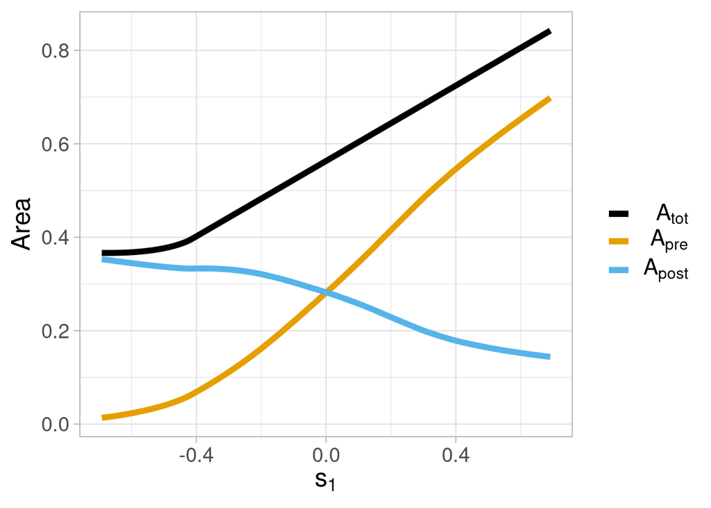

```r
ggplot(data.frame(x = c(-1, 1) * sd_score[1]), aes(x = x)) +
  stat_function(fun = computeAs1, args = list(interval = 0), aes(color = "A"), size = 2) +
  stat_function(fun = computeAs1, args = list(interval = 1), aes(color = "A1"), size = 2) +
  stat_function(fun = computeAs1, args = list(interval = 2), aes(color = "A2"), size = 2) +
  scale_color_manual(values = c("black", "#E69F00", "#56B4E9"),
                     labels = c(expression(A[tot]), expression(A[pre]), expression(A[post])),
                     name = "") +
  xlab(expression(s[1])) + ylab("Area") +
  theme_light(base_size = 16) +
  theme(text = element_text(size = 18), legend.text = element_text(size = 16))
```

This plot shows how the areas $A_{tot}$, $A_{pre}$, and $A_{post}$ change in response to s1. If you compare this to the plot above (first row), you can confirm that low values of s1 correspond to hardly any pre-aspiration and more post-aspiration, while high values of s1 correspond to strong pre- and much less post-aspiration.

## 4.4 Mixed Model

The next step is to connect the results from FPCA to the speaker attributes (i.e., age and region) and cluster type (st, sp, sk). First, let’s take a look at some boxplots to get a first impression:

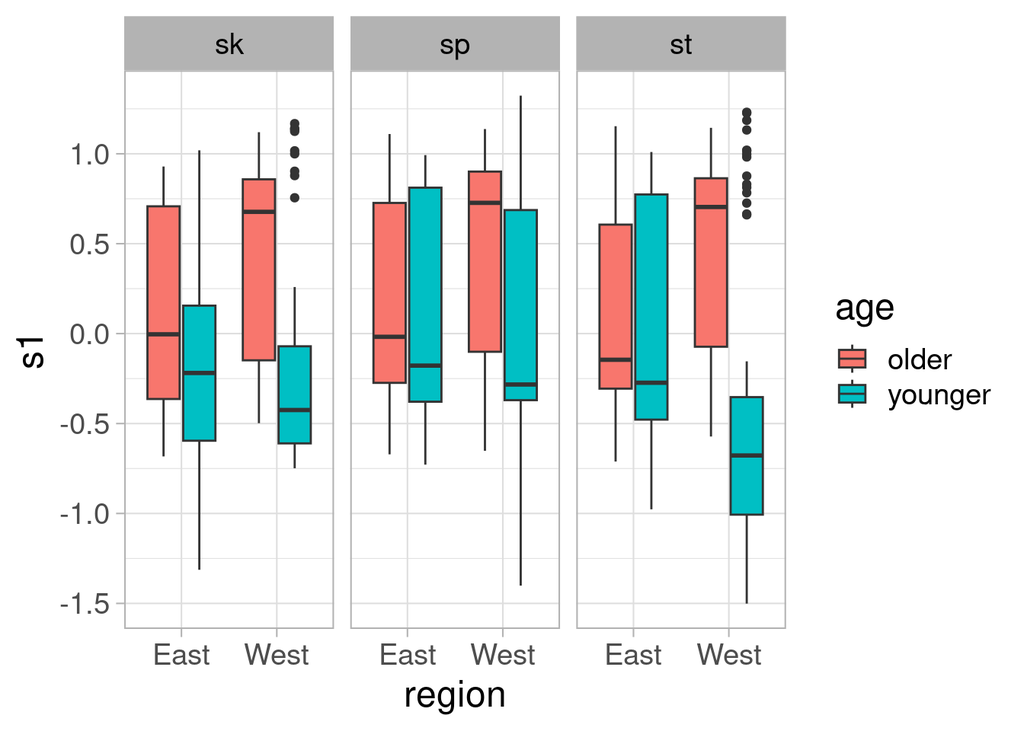

```r
ggplot(info) +
  aes(x = region, y = s1, fill = age) +
  facet_grid(.~cluster) +
  geom_boxplot() +
  theme_light(base_size = 16) +
  theme(text = element_text(size = 18),
        strip.text.x = element_text(color = "black"),
        strip.text.y = element_text(color = "black"))
```

```r
s1.lmer <- lmer(s1 ~ (age + region + cluster)^3 + (age + region | word) + (cluster | speaker),
     data = info,
     control = lmerControl(optimizer = "optimx", optCtrl = list(method = "nlminb"))) %>%
  step() %>%
  get_model()
```

[output not shown]

```r
# s1 model without speaker slope for cluster
s1.lmer <- lmer(s1 ~ age + (1 | speaker) + (1 | word),
                data = info,
                control = lmerControl(optimizer = "optimx", optCtrl = list(method = "nlminb")))
# saveRDS(s1.lmer, file = "./s1.lmer.rds")

# check results
summary(s1.lmer)
```

```
## Linear mixed model fit by REML. t-tests use Satterthwaite's method [
## lmerModLmerTest]
## Formula: s1 ~ age + (1 | speaker) + (1 | word)
##    Data: info
## Control: lmerControl(optimizer = "optimx", optCtrl = list(method = "nlminb"))
##
## REML criterion at convergence: 918.9
##
## Scaled residuals:
##     Min      1Q  Median      3Q     Max
## -2.8682 -0.5294 -0.0309  0.4829  3.4543
##
## Random effects:
##  Groups   Name        Variance Std.Dev.
##  word     (Intercept) 0.07750  0.2784
##  speaker  (Intercept) 0.07557  0.2749
##  Residual             0.22054  0.4696
## Number of obs: 581, groups:  word, 52; speaker, 47
##
## Fixed effects:
##             Estimate Std. Error       df t value Pr(>|t|)
## (Intercept)  0.11346    0.07993 85.44571   1.419    0.159
## ageyounger  -0.25001    0.09618 54.07386  -2.599    0.012 *
## ---
## Signif. codes:  0 '***' 0.001 '**' 0.01 '*' 0.05 '.' 0.1 ' ' 1
##
## Correlation of Fixed Effects:
##            (Intr)
## ageyounger -0.637
```

There is a significant influence of age on s1 (t[54.1] = 2.6, p < 0.05)! Using the function `r.squaredGLMM()`, we can find out how much variance in the first PC score is described by the fixed effects alone (marginal $R^2$) and by the fixed and random effects together (conditional $R^2$).

```r
r.squaredGLMM(s1.lmer)
```

```
##             R2m       R2c
## [1,] 0.03830455 0.4323179
```